```python
import pandas as pd

df = pd.read_excel("superstore.xls", sheet_name="Orders")
df.shape
```

```
(9994, 26)
```

```python
df.columns
```

```
Index(['Row ID', 'Order ID', 'Order Date', 'Ship Date', 'Ship Mode',
       'Customer ID', 'Customer Name', 'Segment', 'Country/Region', 'City',
       'State', 'Postal Code', 'Region', 'Product ID', 'Category',
       'Sub-Category', 'Product Name', 'Sales', 'Quantity', 'Discount',
       'Profit', 'totalsale', 'profit', 'average', 'ordervalue', 'margin'],
      dtype='object')
```

```python
df.head
```

```
<bound method NDFrame.head of       Row ID        Order ID Order Date  Ship Date       Ship Mode  \
0          1  CA-2020-152156 2020-11-08 2020-11-11    Second Class
1          2  CA-2020-152156 2020-11-08 2020-11-11    Second Class
2          3  CA-2020-138688 2020-06-12 2020-06-16    Second Class
3          4  US-2019-108966 2019-10-11 2019-10-18  Standard Class
4          5  US-2019-108966 2019-10-11 2019-10-18  Standard Class
...      ...             ...        ...        ...             ...
9989    9990  CA-2018-110422 2018-01-21 2018-01-23    Second Class
9990    9991  CA-2021-121258 2021-02-26 2021-03-03  Standard Class
9991    9992  CA-2021-121258 2021-02-26 2021-03-03  Standard Class
9992    9993  CA-2021-121258 2021-02-26 2021-03-03  Standard Class
9993    9994  CA-2021-119914 2021-05-04 2021-05-09    Second Class

     Customer ID     Customer Name    Segment Country/Region             City  \
0       CG-12520       Claire Gute   Consumer  United States        Henderson
```

[output cut: 51 more lines]

```python
df.info()
```

```
<class 'pandas.core.frame.DataFrame'>
RangeIndex: 9994 entries, 0 to 9993
Data columns (total 26 columns):
 #   Column          Non-Null Count  Dtype
---  ------          --------------  -----
 0   Row ID          9994 non-null   int64
 1   Order ID        9994 non-null   object
 2   Order Date      9994 non-null   datetime64[ns]
 3   Ship Date       9994 non-null   datetime64[ns]
 4   Ship Mode       9994 non-null   object
 5   Customer ID     9994 non-null   object
 6   Customer Name   9994 non-null   object
 7   Segment         9994 non-null   object
 8   Country/Region  9994 non-null   object
 9   City            9994 non-null   object
```

[output cut: 18 more lines]

```python
df['Sales'].sum()
```

```
np.float64(2297200.8603)
```

```python
df['Profit'].sum()
```

```
np.float64(286397.0216999999)
```

```python
df['Order ID'].nunique()
```

```
5009
```

```python
df['Sales'].sum() / df ['Order ID'].nunique()
```

```
np.float64(458.6146656618087)
```

```python
total_sales =df['Sales'].sum()
total_sales
```

```
np.float64(2297200.8603)
```

```python
total_Profit =df['Profit'].sum()
total_Profit
```

```
np.float64(286397.0216999999)
```

```python
total_orders = df['Order ID'].nunique()
total_orders
```

```
5009
```

```python
avg_order_value = total_sales/total_orders
avg_order_value
```

```
np.float64(458.6146656618087)
```

```python
category_summary = df.groupby('Category')[['Sales','Profit']].sum().sort_values(by='Sales', ascending=False)
category_summary
```

| Category | Sales | Profit |
| --- | --- | --- |
| Technology | 836154.0330 | 145454.9481 |
| Furniture | 741999.7953 | 18451.2728 |
| Office Supplies | 719047.0320 | 122490.8008 |

```python
!pip install matplotlib
```

```python
!pip install matplotlib
```

```python
import matplotlib.pyplot as plt
```

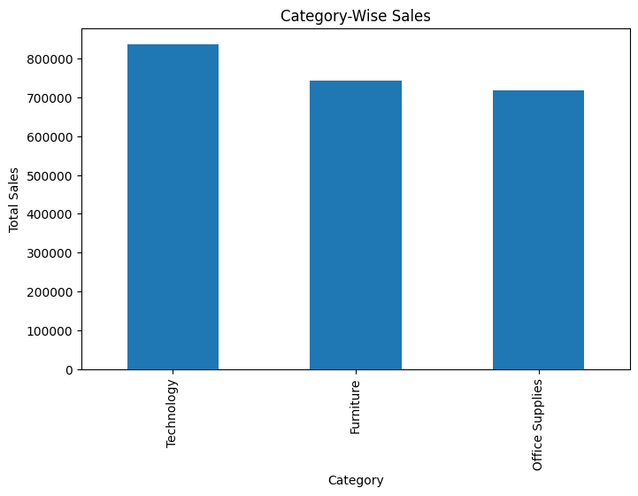

```python
category_summary['Sales'].plot(kind='bar', figsize=(8,5))
plt.title('Category-Wise Sales')
plt.ylabel('Total Sales')
plt.xlabel('Category')
plt.show()
```

```python
category_summary['Profit_Margin_%'] = (
    category_summary['Profit'] / category_summary['Sales']
) * 100

category_summary
```

| Category | Sales | Profit | Profit_Margin_% |
| --- | --- | --- | --- |
| Technology | 836154.0330 | 145454.9481 | 17.395712 |
| Furniture | 741999.7953 | 18451.2728 | 2.486695 |
| Office Supplies | 719047.0320 | 122490.8008 | 17.035158 |

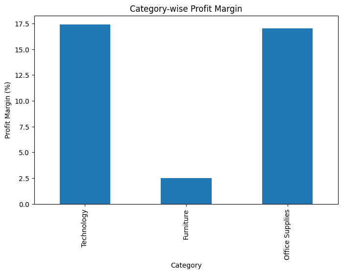

```python
category_summary['Profit_Margin_%'].plot(kind='bar', figsize=(8,5))
plt.title('Category-wise Profit Margin')
plt.ylabel('Profit Margin (%)')
plt.xlabel('Category')
plt.show()
```

## Objective

The objective of this project is to analyze sales, profit, and customer behavior.

```python
df.head()
```

|  | Row ID | Order ID | Order Date | Ship Date | Ship Mode | Customer ID | Customer Name | Segment | Country/Region | City | ... | Product Name | Sales | Quantity | Discount | Profit | totalsale | profit | average | ordervalue | margin |
| --- | --- | --- | --- | --- | --- | --- | --- | --- | --- | --- | --- | --- | --- | --- | --- | --- | --- | --- | --- | --- | --- |
| 0 | 1 | CA-2020-152156 | 2020-11-08 | 2020-11-11 | Second Class | CG-12520 | Claire Gute | Consumer | United States | Henderson | ... | Bush Somerset Collection Bookcase | 261.9600 | 2 | 0.00 | 41.9136 | 2.297201e+06 | 286397.0217 | 9995.0 | 143198.51085 | 0.124672 |
| 1 | 2 | CA-2020-152156 | 2020-11-08 | 2020-11-11 | Second Class | CG-12520 | Claire Gute | Consumer | United States | Henderson | ... | Hon Deluxe Fabric Upholstered Stacking Chairs,... | 731.9400 | 3 | 0.00 | 219.5820 | NaN | NaN | NaN | NaN | NaN |
| 2 | 3 | CA-2020-138688 | 2020-06-12 | 2020-06-16 | Second Class | DV-13045 | Darrin Van Huff | Corporate | United States | Los Angeles | ... | Self-Adhesive Address Labels for Typewriters b... | 14.6200 | 2 | 0.00 | 6.8714 | NaN | NaN | NaN | NaN | NaN |
| 3 | 4 | US-2019-108966 | 2019-10-11 | 2019-10-18 | Standard Class | SO-20335 | Sean O'Donnell | Consumer | United States | Fort Lauderdale | ... | Bretford CR4500 Series Slim Rectangular Table | 957.5775 | 5 | 0.45 | -383.0310 | NaN | NaN | NaN | NaN | NaN |
| 4 | 5 | US-2019-108966 | 2019-10-11 | 2019-10-18 | Standard Class | SO-20335 | Sean O'Donnell | Consumer | United States | Fort Lauderdale | ... | Eldon Fold 'N Roll Cart System | 22.3680 | 2 | 0.20 | 2.5164 | NaN | NaN | NaN | NaN | NaN |

5 rows × 26 columns

```python
region_summary = (
    df.groupby('Region')[['Sales', 'Profit']]
    .sum()
    .sort_values(by='Sales', ascending=False)
)

region_summary
```

| Region | Sales | Profit |
| --- | --- | --- |
| West | 725457.8245 | 108418.4489 |
| East | 678781.2400 | 91522.7800 |
| Central | 501239.8908 | 39706.3625 |
| South | 391721.9050 | 46749.4303 |

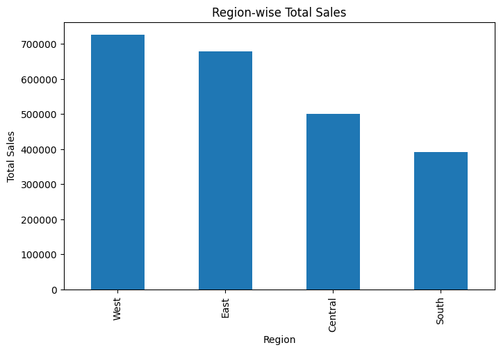

```python
import matplotlib.pyplot as plt

region_summary['Sales'].plot(kind='bar', figsize=(8,5))
plt.title('Region-wise Total Sales')
plt.ylabel('Total Sales')
plt.xlabel('Region')
plt.show()
```

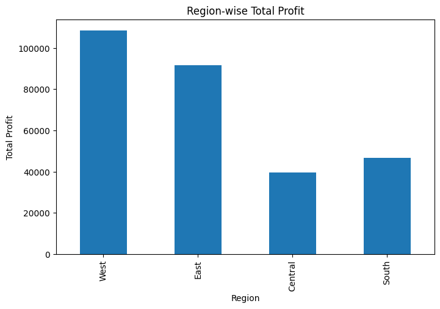

```python
region_summary['Profit'].plot(kind='bar', figsize=(8,5))
plt.title('Region-wise Total Profit')
plt.ylabel('Total Profit')
plt.xlabel('Region')
plt.show()
```

### Key Insights (Region-wise)

- Certain regions generate high sales but relatively lower profit.
- This indicates potential issues such as higher discounts or operational costs.
- Regions with both high sales and profit should be prioritized for expansion.

```python
segment_summary = (
    df.groupby('Segment')[['Sales', 'Profit']]
    .sum()
    .sort_values(by='Sales', ascending=False)
)

segment_summary
```

| Segment | Sales | Profit |
| --- | --- | --- |
| Consumer | 1.161401e+06 | 134119.2092 |
| Corporate | 7.061464e+05 | 91979.1340 |
| Home Office | 4.296531e+05 | 60298.6785 |

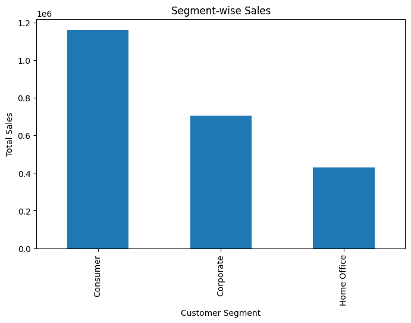

```python
import matplotlib.pyplot as plt

segment_summary['Sales'].plot(kind='bar', figsize=(8,5))
plt.title('Segment-wise Sales')
plt.ylabel('Total Sales')
plt.xlabel('Customer Segment')
plt.show()
```

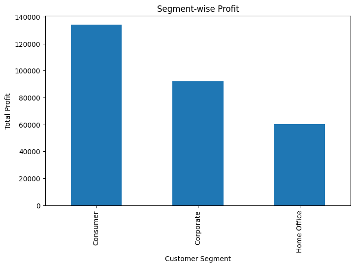

```python
segment_summary['Profit'].plot(kind='bar', figsize=(8,5))
plt.title('Segment-wise Profit')
plt.ylabel('Total Profit')
plt.xlabel('Customer Segment')
plt.show()
```

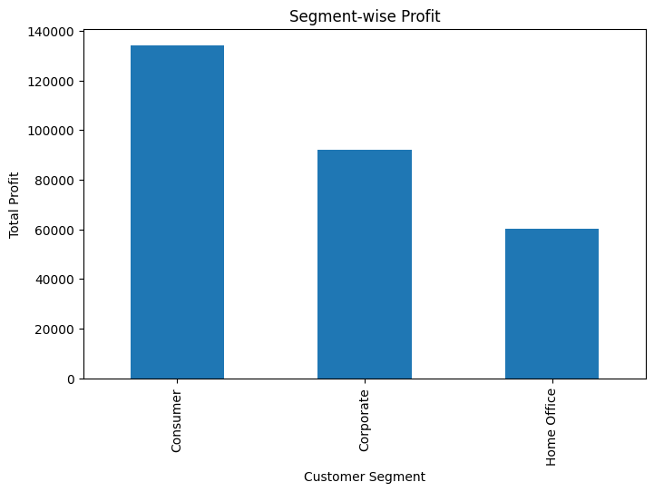

```python
segment_summary['Profit'].plot(kind='bar', figsize=(8,5))
plt.title('Segment-wise Profit')
plt.ylabel('Total Profit')
plt.xlabel('Customer Segment')
plt.show()
```

### Customer Segment Insights

- The Consumer segment contributes the highest sales volume.
- Corporate customers show strong profitability with fewer orders.
- Home Office segment has lower contribution and may require targeted promotions.

**Business Recommendation:**  
Focus on retaining Corporate customers while optimizing discounts for Consumer buyers.

```python
loss_df = df[df['Profit'] < 0]
loss_df.shape
```

```
(1871, 26)
```

```python
loss_products = (
    loss_df.groupby('Product Name')[['Sales', 'Profit']]
    .sum()
    .sort_values(by='Profit')
    .head(10)
)

loss_products
```

| Product Name | Sales | Profit |
| --- | --- | --- |
| Cubify CubeX 3D Printer Double Head Print | 6299.979 | -9239.9692 |
| GBC DocuBind P400 Electric Binding System | 4899.564 | -6859.3896 |
| Lexmark MX611dhe Monochrome Laser Printer | 13769.919 | -5269.9690 |
| GBC Ibimaster 500 Manual ProClick Binding System | 6696.624 | -5098.5660 |
| GBC DocuBind TL300 Electric Binding System | 4395.251 | -4162.0336 |
| Cubify CubeX 3D Printer Triple Head Print | 7999.980 | -3839.9904 |
| Fellowes PB500 Electric Punch Plastic Comb Binding Machine with Manual Bind | 2287.782 | -3431.6730 |
| Chromcraft Bull-Nose Wood Oval Conference Tables & Bases | 8264.700 | -3107.5272 |
| Ibico EPK-21 Electric Binding System | 1889.990 | -2929.4845 |
| Bush Advantage Collection Racetrack Conference Table | 6151.045 | -2545.2600 |

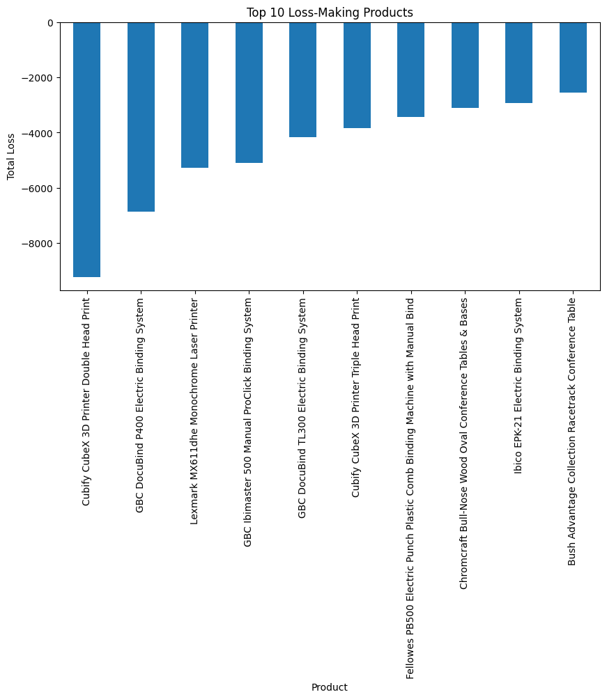

```python
loss_products['Profit'].plot(kind='bar', figsize=(10,5))
plt.title('Top 10 Loss-Making Products')
plt.ylabel('Total Loss')
plt.xlabel('Product')
plt.show()
```

### Loss-Making Product Insights

- A small number of products contribute disproportionately to overall losses.
- These losses may be driven by heavy discounting, low margins, or high shipping costs.
- Addressing these products can significantly improve overall profitability.

**Business Recommendation:**  
Review pricing and discount strategies for these products and consider discontinuation if margins cannot be improved.

## Executive Summary

This project analyzes the business performance of a retail superstore using transaction-level sales data.

### Business Recommendations

- Focus marketing and inventory investments on Technology products.
- Review pricing and discount strategies for Furniture category.
- Strengthen retention strategies for Corporate customers.
- Re-evaluate or reprice loss-making products to improve overall profitability.